# Wrangle and Analyze Data Report

### Introduction

This project focused on wrangling data from the WeRateDogs Twitter account using Python, documented in a Jupyter Notebook (wrangle_act.ipynb). This Twitter account rates dogs with humorous commentary. The rating denominator is usually 10, however, the numerators are usually greater than 10. They’re Good Dogs Brent wrangle WeRateDogs Twitter data to create interesting and trustworthy analyses and visualizations. WeRateDogs has over 4 million followers and has received international media coverage.

## Twitter-archive-enhanced Dataset

### Quality Issues

- Missing data in the following columns:  
  1) in_reply_to_status_id,  
  2) in_reply_to_user_id,  
  3) retweeted_status_id,  
  4) etweeted_status_user_id,  
  5) retweeted_status_timestamp,  
  6) expanded_urls
- Source columns have HTML tags
- Timestamp and retweeted_status_timestamp is in object datatype
- This dataset includes retweets, which means there is duplicated data
- retweeted_status_id column possess float datatype but it should be int formate
- Some of the Dogs name have been entered wrongly such as 'None', 'a', 'an', 'by' and some more

### Tidiness Issues

- The variable for the dog's stage (dogoo, floofer, pupper, puppo) is spread in different columns

### Quality Issues

- Dog breeds are not consistently in p1,p2,p3 columns

### Tidiness Issues:

- This data set is part of the same observational unit as the data in the Twitter-archive-enhanced Dataset

### Quality Issues

- tweet_id is an object

### Tidiness Issues:

- This data set is also part of the same observational unit as the data in the Twitter-archive-enhanced Dataset

### Commenly used dog names?

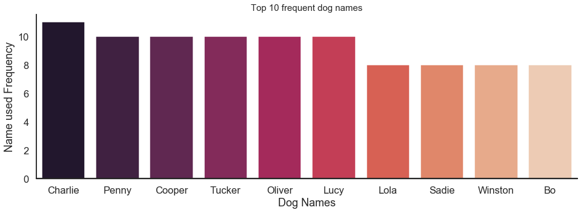

###### Most of the dogs names are: 'Charlie', 'Penny', 'Cooper', 'Tucker', 'Oliver', 'Lucy', 'Lola', 'Sadie', 'Winston', 'Bo'

### Most common pet dog breeds are :

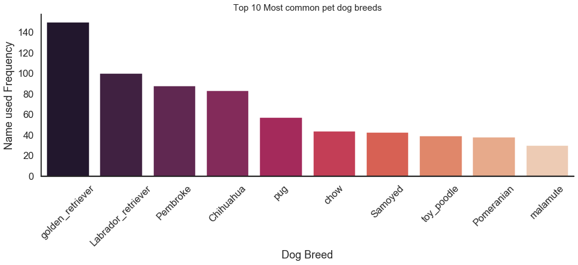

###### Most common pet dog breeds are: golden_retriever, Labrador_retriever, Pembroke, Chihuahua, pug, chow, Samoyed, toy_poodle, Pomeranian, malamute

### Top 10 Highest Tweet in which date

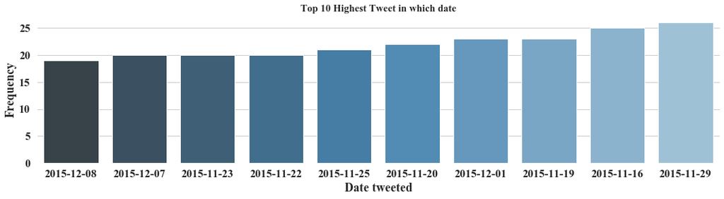

## Analysis

### Problem's Addressed

- The dog_breed column is created based on the the high confidence level and 'p1_dog', 'p2_dog' and 'p3_dog' statements
- dropped this columns (doggo, floofer, pupper, puppo) because they have the high range of nan values
- tweet_id is set as object type as it is not going to use for calculation.
- A main dataframe is created using tweet_api, img_df, and tweet_df dataframes
- Dog Names Issue got rectified
- Inconsistency in dog_breed got removed
- All retweets get deleted to get unique tweets
- The columns such as in_reply_to_status_id, in_reply_to_user_id, retweeted_status_id, retweeted_status_user_id, and retweeted_status_timestamp is removed which is not needed
- Timestamp format got corrected to datetime format
- Extra HTML tags from source column get refracted
- Dog ratings get standardized.